# CAUV Projections, 2020 and beyond

Robert Dinterman

2020-06-25

# Key Findings

## Highlights

- Current projection for average CAUV value in 2020 is $665 which would represent a change of -24% from the previous tax year. This is the first year without the “phase-in”.
  - From 2017-2020 a -42% decrease in average CAUV values for counties receiving updates to their property taxes.
- The projection for the average CAUV value in 2021 is $760. The average CAUV value projections could end up as low as $560 or as high as $900.
  - From 2018-2021 a -25% change from the previous triennial update.
- The very early projection for the average CAUV value in 2022 is $880. The average CAUV value projections could end up as low as $665 or as high as $1,010.
  - From 2019-2022 a 1% change from the previous triennial update.

## Expectations

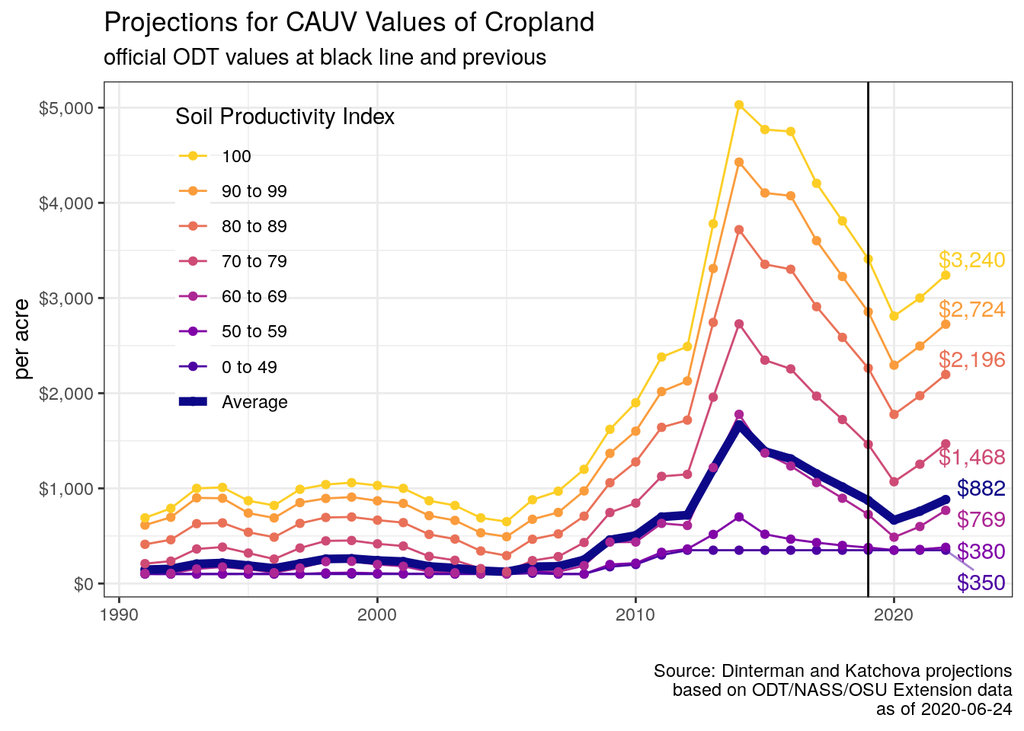

## Expectations

Expected CAUV Projections

| Year | avg_cauv | indx_49 | indx_59 | indx_69 | indx_79 | indx_89 | indx_99 | indx_100 |
| --- | --- | --- | --- | --- | --- | --- | --- | --- |
| 2007 | $181 | $100 | $100 | $123 | $283 | $521 | $747 | $970 |
| 2008 | $249 | $100 | $100 | $188 | $431 | $708 | $973 | $1,200 |
| 2009 | $459 | $176 | $200 | $435 | $746 | $1,059 | $1,368 | $1,620 |
| 2010 | $505 | $200 | $214 | $436 | $845 | $1,278 | $1,601 | $1,900 |
| 2011 | $700 | $300 | $328 | $632 | $1,126 | $1,641 | $2,017 | $2,380 |
| 2012 | $719 | $350 | $363 | $610 | $1,147 | $1,717 | $2,128 | $2,490 |
| 2013 | $1,205 | $350 | $516 | $1,218 | $1,958 | $2,743 | $3,310 | $3,780 |
| 2014 | $1,668 | $350 | $700 | $1,778 | $2,728 | $3,718 | $4,428 | $5,030 |
| 2015 | $1,388 | $350 | $518 | $1,371 | $2,347 | $3,354 | $4,104 | $4,770 |
| 2016 | $1,310 | $350 | $466 | $1,235 | $2,255 | $3,302 | $4,074 | $4,750 |
| 2017 | $1,153 | $350 | $430 | $1,061 | $1,969 | $2,909 | $3,602 | $4,205 |
| 2018 | $1,015 | $350 | $400 | $896 | $1,723 | $2,586 | $3,226 | $3,810 |
| 2019 | $873 | $350 | $378 | $725 | $1,462 | $2,263 | $2,855 | $3,410 |
| 2020 | $666 | $350 | $351 | $487 | $1,069 | $1,777 | $2,294 | $2,810 |
| 2021 | $759 | $350 | $359 | $599 | $1,254 | $1,974 | $2,495 | $3,000 |
| 2022 | $882 | $350 | $380 | $769 | $1,468 | $2,196 | $2,724 | $3,240 |

## Updates

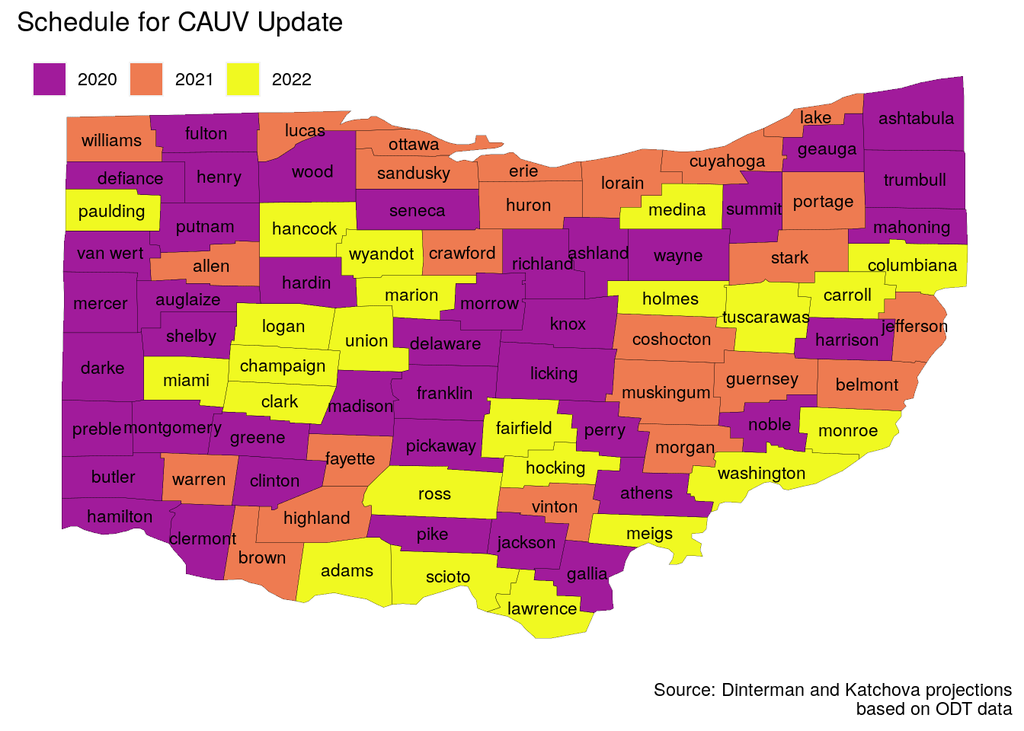

# CAUV Calculation

## CAUV Calculation Overview

> It is the expected net present value of an acre of land based. To determine this, first a historical average of yields and prices for corn, soybeans, and wheat to determine gross income. Then historical non-land costs – compliments of The Ohio State University Agricultural Extension Agency – are subtracted from gross income for a measure of net income. And finally, this net income is divided by a capitalization rate based upon historical values of farm interest and equity rates. This value will vary based upon the particular soil type(s) for a farm.

## CAUV Calculation Overview

- A CAUV value is assigned for each of the 3,514 soil types in Ohio
  - based on their expected yields of corn, soybeans, and wheat from the last state-wide soil survey in 1984
- Value is the expected net present value based on the past 5 to 10 years worth of data for each component
  - Economics jargon, it is the net operating income divided by **capitalization rate**
- Net operating income is based off of the expected revenue (**price** times **yield**) less the expected costs (only **non-land costs**). Calculated for corn, soybeans, and wheat.
- **Capitalization rate** is a combination of the interest rate on a loan for purchasing farmland along with appreciation rate of farmland.

## Generic Formula

- CAUV is assigned for each soil type, although what really matters is the yields that soil type had for corn, soybeans, and wheat in 1984:

$$CAUV_{s,t} = \frac{NOI_{s,t}}{CAP_t}$$

- where $CAP_t$ represents the capitalization rate and $NOI_{s,t}$ represents the net operating income based on revenues less non-land costs for corn, soybeans, and wheat.
- Net operating income, ${NOI_{s,t}}$, captures the average returns to an acre of land under normal management practices which is adjusted by the state-wide rotation pattern of commodities.

## Generic Formula

- ${NOI_{s,t}}$ can be defined as:

$$NOI_{s,t} = \sum_{c} w_{c,t}\times(GOI_{s,c,t} - {nonland}_{s,c,t})$$

- where $w_{c,t}$ represents a commodities share of total harvested acreage
- $GOI_{s,c,t}$ is the expected revenues for a soil type depending on the statewide price of a commodity and yield is a percentage adjustment to the soil’s yield in 1984 for each commodity:

$$GOI_{s,c,t} = Price_{c,Ohio,t} \times \left( \frac{Yield_{c,Ohio,t}}{Yield_{c,Ohio,1984}} \times Yield_{c,s,1984} \right)$$

# Component Trends

## Non-Land Costs

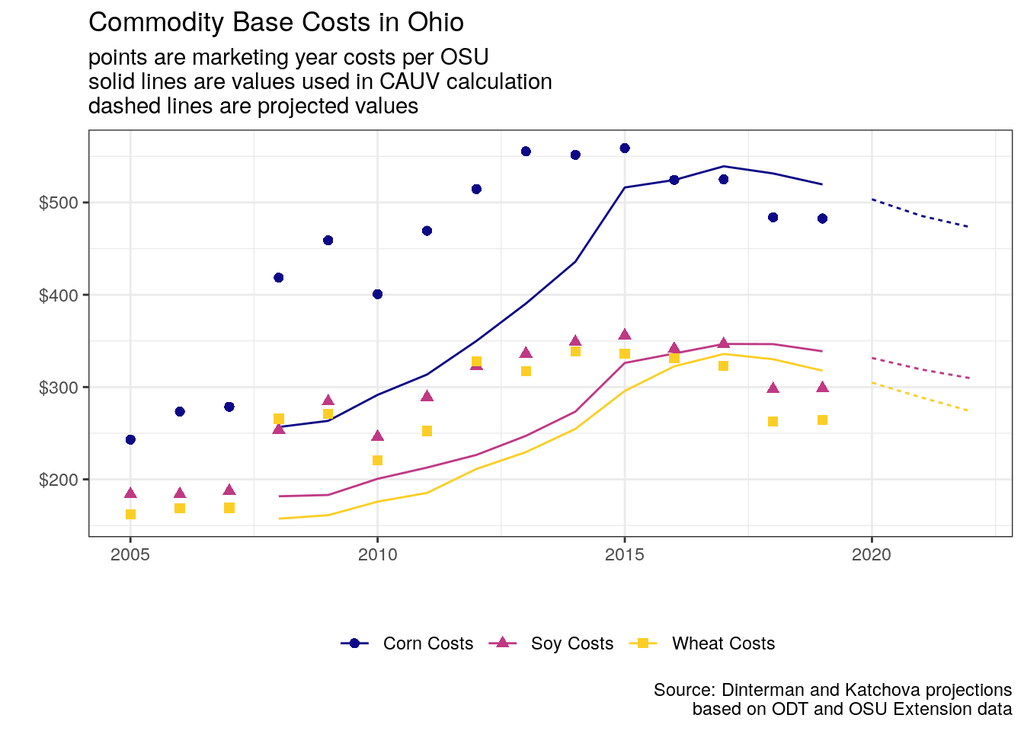

## Prices

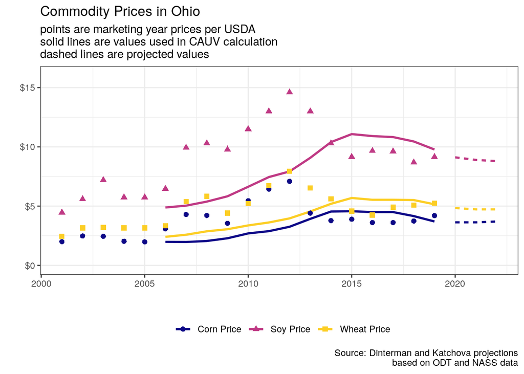

## Yields

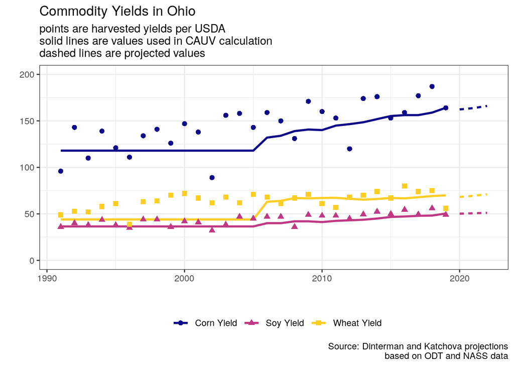

## Capitalization Rate

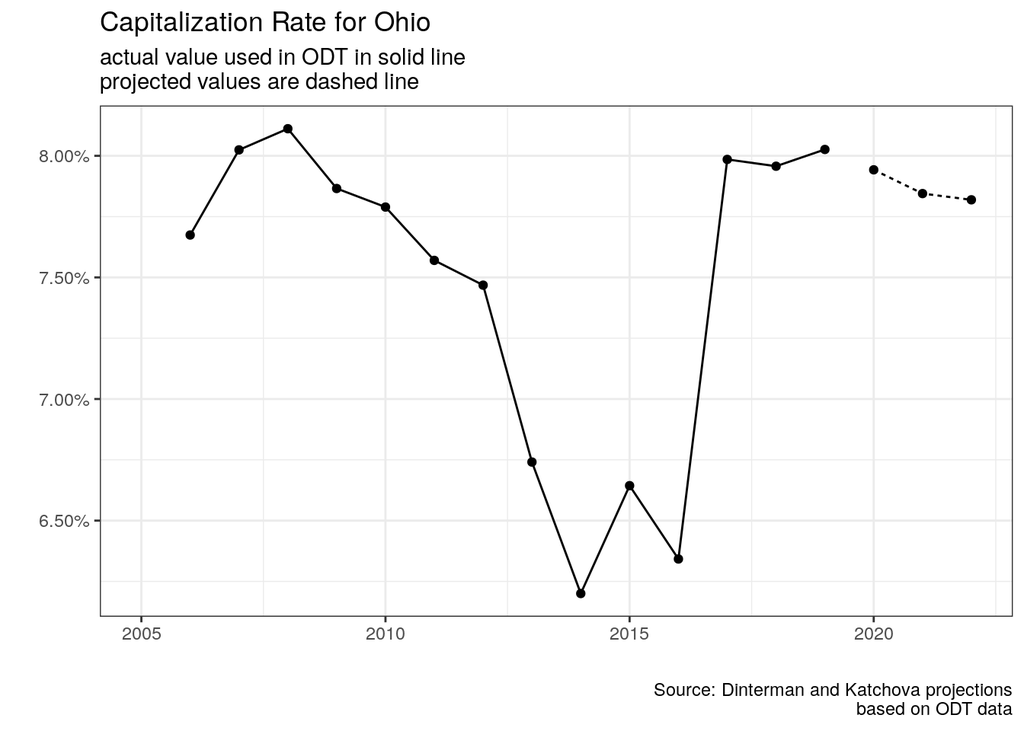

# Component Values

## Rotations

Historical Corn Rotation

| Year | ODT Value | USDA Acres Harvested | AVG Acres Harvested | Projected |
| --- | --- | --- | --- | --- |
| 2010 | 39.0% | 3,270,000 | 3,210,000 | 37.5% |
| 2011 | 38.6% | 3,200,000 | 3,216,000 | 37.4% |
| 2012 | 38.6% | 3,650,000 | 3,220,000 | 37.5% |
| 2013 | 38.7% | 3,740,000 | 3,268,000 | 38.0% |
| 2014 | 38.6% | 3,480,000 | 3,276,000 | 38.0% |
| 2015 | 40.0% | 3,260,000 | 3,468,000 | 39.9% |
| 2016 | 40.2% | 3,300,000 | 3,466,000 | 40.0% |
| 2017 | 40.0% | 3,150,000 | 3,486,000 | 40.1% |
| 2018 | 39.0% | 3,300,000 | 3,386,000 | 39.0% |
| 2019 | 38.0% | 2,570,000 | 3,298,000 | 38.0% |
| 2020 | - | - | 3,116,000 | 37.2% |
| 2021 | - | - | 3,103,568 | 37.0% |
| 2022 | - | - | 3,082,338 | 36.9% |

Historical Soybean Rotation

| Year | ODT Value | USDA Acres Harvested | AVG Acres Harvested | Projected |
| --- | --- | --- | --- | --- |
| 2010 | 51.0% | 4,590,000 | 4,448,000 | 52.0% |
| 2011 | 50.9% | 4,540,000 | 4,470,000 | 52.0% |
| 2012 | 51.1% | 4,590,000 | 4,492,000 | 52.2% |
| 2013 | 51.2% | 4,490,000 | 4,476,000 | 52.0% |
| 2014 | 52.0% | 4,690,000 | 4,546,000 | 52.7% |
| 2015 | 52.6% | 4,740,000 | 4,580,000 | 52.7% |
| 2016 | 53.0% | 4,840,000 | 4,610,000 | 53.2% |
| 2017 | 54.0% | 5,090,000 | 4,670,000 | 53.7% |
| 2018 | 55.0% | 5,020,000 | 4,770,000 | 54.9% |
| 2019 | 56.0% | 4,270,000 | 4,876,000 | 56.2% |
| 2020 | - | - | 4,792,000 | 57.2% |
| 2021 | - | - | 4,825,122 | 57.5% |
| 2022 | - | - | 4,844,583 | 58.0% |

Historical Wheat Rotation

| Year | ODT Value | USDA Acres Harvested | AVG Acres Harvested | Projected |
| --- | --- | --- | --- | --- |
| 2010 | 10.0% | 700,000 | 900,000 | 10.5% |
| 2011 | 10.5% | 850,000 | 912,000 | 10.6% |
| 2012 | 10.3% | 450,000 | 886,000 | 10.3% |
| 2013 | 10.1% | 640,000 | 864,000 | 10.0% |
| 2014 | 9.4% | 545,000 | 808,000 | 9.4% |
| 2015 | 7.4% | 480,000 | 637,000 | 7.3% |
| 2016 | 6.8% | 560,000 | 593,000 | 6.8% |
| 2017 | 6.0% | 460,000 | 535,000 | 6.2% |
| 2018 | 6.0% | 450,000 | 537,000 | 6.2% |
| 2019 | 6.0% | 385,000 | 499,000 | 5.8% |
| 2020 | - | - | 467,000 | 5.6% |
| 2021 | - | - | 458,917 | 5.5% |
| 2022 | - | - | 429,210 | 5.1% |

## Non-Land Costs

Historical Corn Base Costs

| Year | ODT Base Cost | Low Projection | Expected Projection | High Projection |
| --- | --- | --- | --- | --- |
| 2010 | $286.65 | - | $291.55 | - |
| 2011 | $300.98 | - | $313.59 | - |
| 2012 | $350.71 | $363.76 | $350.02 | $306.90 |
| 2013 | $391.90 | $402.66 | $390.51 | $346.77 |
| 2014 | $437.85 | $447.49 | $435.82 | $387.01 |
| 2015 | $516.99 | $534.55 | $516.25 | $482.29 |
| 2016 | $524.47 | $544.03 | $524.36 | $501.26 |
| 2017 | $538.78 | $558.62 | $539.19 | $520.37 |
| 2018 | $529.28 | $560.31 | $531.44 | $526.53 |
| 2019 | $517.63 | $551.90 | $519.53 | $508.91 |
| 2020 | - | $530.45 | $503.44 | $491.73 |
| 2021 | - | $510.53 | $485.49 | $475.64 |
| 2022 | - | $493.00 | $473.14 | $463.06 |

Historical Corn Additional Costs

| Year | ODT Add Cost | Low Projection | Expected Projection | High Projection |
| --- | --- | --- | --- | --- |
| 2010 | $0.83 | - | $0.86 | - |
| 2011 | $0.84 | - | $0.89 | - |
| 2012 | $0.90 | $1.04 | $0.97 | $0.89 |
| 2013 | $1.04 | $1.15 | $1.06 | $0.94 |
| 2014 | $1.18 | $1.28 | $1.20 | $1.05 |
| 2015 | $1.36 | $1.45 | $1.38 | $1.24 |
| 2016 | $1.38 | $1.45 | $1.36 | $1.30 |
| 2017 | $1.45 | $1.55 | $1.49 | $1.41 |
| 2018 | $1.44 | $1.54 | $1.45 | $1.42 |
| 2019 | $1.43 | $1.54 | $1.44 | $1.35 |
| 2020 | - | $1.50 | $1.38 | $1.32 |
| 2021 | - | $1.45 | $1.33 | $1.27 |
| 2022 | - | $1.40 | $1.34 | $1.27 |

Historical Soybean Base Costs

| Year | ODT Base Cost | Low Projection | Expected Projection | High Projection |
| --- | --- | --- | --- | --- |
| 2010 | $189.10 | - | $200.60 | - |
| 2011 | $204.60 | - | $212.78 | - |
| 2012 | $227.51 | $238.30 | $226.51 | $205.28 |
| 2013 | $248.69 | $254.03 | $247.15 | $222.20 |
| 2014 | $275.21 | $281.06 | $273.38 | $244.93 |
| 2015 | $325.42 | $336.37 | $326.13 | $303.99 |
| 2016 | $336.33 | $345.95 | $336.36 | $317.16 |
| 2017 | $347.10 | $357.99 | $346.71 | $332.70 |
| 2018 | $346.26 | $362.64 | $346.52 | $338.62 |
| 2019 | $338.54 | $360.34 | $338.75 | $329.80 |
| 2020 | - | $349.33 | $331.51 | $321.80 |
| 2021 | - | $336.63 | $319.02 | $310.20 |
| 2022 | - | $325.48 | $309.54 | $300.68 |

Historical Soybean Additional Costs

| Year | ODT Add Cost | Low Projection | Expected Projection | High Projection |
| --- | --- | --- | --- | --- |
| 2010 | $0.66 | - | $0.71 | - |
| 2011 | $0.77 | - | $0.86 | - |
| 2012 | $0.93 | $1.13 | $1.06 | $0.80 |
| 2013 | $1.12 | $1.29 | $1.15 | $0.95 |
| 2014 | $1.27 | $1.45 | $1.30 | $1.10 |
| 2015 | $1.24 | $1.34 | $1.10 | $1.14 |
| 2016 | $1.07 | $1.14 | $1.06 | $1.06 |
| 2017 | $1.05 | $1.13 | $1.00 | $1.04 |
| 2018 | $0.94 | $1.03 | $0.96 | $0.93 |
| 2019 | $0.90 | $0.98 | $0.91 | $0.83 |
| 2020 | - | $0.96 | $0.89 | $0.80 |
| 2021 | - | $0.93 | $0.82 | $0.77 |
| 2022 | - | $0.90 | $0.91 | $0.79 |

Historical Wheat Base Costs

| Year | ODT Base Cost | Low Projection | Expected Projection | High Projection |
| --- | --- | --- | --- | --- |
| 2010 | $170.16 | - | $175.87 | - |
| 2011 | $192.94 | - | $185.33 | - |
| 2012 | $211.52 | $217.51 | $211.31 | $187.49 |
| 2013 | $230.62 | $234.77 | $229.55 | $204.75 |
| 2014 | $255.48 | $268.00 | $254.67 | $226.00 |
| 2015 | $296.98 | $302.24 | $295.82 | $265.12 |
| 2016 | $323.52 | $329.83 | $322.51 | $296.39 |
| 2017 | $336.21 | $347.67 | $335.87 | $315.83 |
| 2018 | $330.53 | $349.23 | $330.11 | $325.75 |
| 2019 | $319.08 | $340.47 | $317.76 | $310.93 |
| 2020 | - | $328.17 | $304.78 | $299.57 |
| 2021 | - | $310.34 | $288.72 | $277.54 |
| 2022 | - | $293.47 | $273.76 | $262.96 |

Historical Wheat Additional Costs

| Year | ODT Add Cost | Low Projection | Expected Projection | High Projection |
| --- | --- | --- | --- | --- |
| 2010 | $1.14 | - | $1.12 | - |
| 2011 | $1.19 | - | $1.25 | - |
| 2012 | $1.41 | $1.58 | $1.47 | $1.25 |
| 2013 | $1.61 | $1.78 | $1.69 | $1.47 |
| 2014 | $1.80 | $1.99 | $1.91 | $1.68 |
| 2015 | $1.77 | $1.94 | $1.74 | $1.77 |
| 2016 | $1.64 | $1.79 | $1.61 | $1.64 |
| 2017 | $1.62 | $1.78 | $1.60 | $1.66 |
| 2018 | $1.49 | $1.68 | $1.57 | $1.49 |
| 2019 | $1.41 | $1.56 | $1.48 | $1.31 |
| 2020 | - | $1.47 | $1.41 | $1.25 |
| 2021 | - | $1.40 | $1.31 | $1.21 |
| 2022 | - | $1.37 | $1.31 | $1.20 |

## Prices

Historical Corn Price

| Year | ODT Price | USDA Price | Low Projection | Expected Projection | High Projection |
| --- | --- | --- | --- | --- | --- |
| 2010 | $2.66 | $5.45 | $2.28 | $2.70 | $2.79 |
| 2011 | $2.89 | $6.44 | $2.57 | $2.89 | $3.05 |
| 2012 | $3.19 | $7.09 | $2.80 | $3.26 | $3.26 |
| 2013 | $3.91 | $4.41 | $3.26 | $3.93 | $3.93 |
| 2014 | $4.48 | $3.78 | $3.93 | $4.54 | $4.54 |
| 2015 | $4.55 | $3.89 | $4.55 | $4.57 | $5.18 |
| 2016 | $4.49 | $3.61 | $4.42 | $4.50 | $5.00 |
| 2017 | $4.51 | $3.61 | $4.50 | $4.50 | $5.09 |
| 2018 | $4.18 | $3.74 | $4.17 | $4.16 | $4.73 |
| 2019 | $3.68 | $4.20 | $3.68 | $3.70 | $4.22 |
| 2020 | - | - | $3.54 | $3.63 | $3.70 |
| 2021 | - | - | $3.54 | $3.63 | $3.63 |
| 2022 | - | - | $3.60 | $3.70 | $3.70 |

Historical Soybean Price

| Year | ODT Price | USDA Price | Low Projection | Expected Projection | High Projection |
| --- | --- | --- | --- | --- | --- |
| 2010 | $6.41 | $11.50 | $5.83 | $6.63 | $6.63 |
| 2011 | $7.22 | $13.00 | $6.63 | $7.45 | $7.42 |
| 2012 | $7.74 | $14.60 | $7.16 | $7.93 | $7.93 |
| 2013 | $8.98 | $13.00 | $7.94 | $9.08 | $9.08 |
| 2014 | $10.13 | $10.30 | $9.08 | $10.40 | $10.40 |
| 2015 | $11.09 | $9.16 | $11.00 | $11.08 | $11.95 |
| 2016 | $10.91 | $9.66 | $10.91 | $10.91 | $11.78 |
| 2017 | $10.83 | $9.62 | $10.77 | $10.83 | $11.78 |
| 2018 | $10.43 | $8.69 | $10.38 | $10.46 | $11.35 |
| 2019 | $9.78 | $9.15 | $9.78 | $9.78 | $10.70 |
| 2020 | - | - | $9.00 | $9.12 | $9.78 |
| 2021 | - | - | $8.79 | $8.90 | $9.12 |
| 2022 | - | - | $8.69 | $8.80 | $8.90 |

Historical Wheat Price

| Year | ODT Price | USDA Price | Low Projection | Expected Projection | High Projection |
| --- | --- | --- | --- | --- | --- |
| 2010 | $3.41 | $5.21 | $3.05 | $3.37 | $3.37 |
| 2011 | $3.64 | $6.73 | $3.37 | $3.62 | $3.95 |
| 2012 | $3.98 | $7.94 | $3.64 | $3.96 | $4.20 |
| 2013 | $4.54 | $6.54 | $3.96 | $4.55 | $4.55 |
| 2014 | $5.16 | $5.60 | $4.55 | $5.19 | $5.19 |
| 2015 | $5.67 | $4.57 | $5.38 | $5.69 | $5.99 |
| 2016 | $5.53 | $4.25 | $5.32 | $5.53 | $6.02 |
| 2017 | $5.53 | $4.90 | $5.53 | $5.53 | $6.02 |
| 2018 | $5.52 | $5.08 | $5.33 | $5.51 | $5.97 |
| 2019 | $5.15 | $5.25 | $4.96 | $5.15 | $5.62 |
| 2020 | - | - | $4.63 | $4.84 | $5.15 |
| 2021 | - | - | $4.51 | $4.73 | $4.84 |
| 2022 | - | - | $4.51 | $4.73 | $4.73 |

## Yields

Historical Corn Yield

| Year | ODT Yield | USDA Yield | Trend Yield | Projected Yield |
| --- | --- | --- | --- | --- |
| 2010 | 140.1 | 160 | 154.4 | 139.7 |
| 2011 | 144.9 | 153 | 156.4 | 144.2 |
| 2012 | 146.5 | 120 | 158.4 | 145.5 |
| 2013 | 148.5 | 174 | 160.4 | 147 |
| 2014 | 151.9 | 176 | 162.3 | 150.1 |
| 2015 | 155.2 | 153 | 164.3 | 153.7 |
| 2016 | 156.2 | 159 | 166.3 | 154.7 |
| 2017 | 156.2 | 177 | 168.3 | 154.7 |
| 2018 | 158.9 | 187 | 170.2 | 157.4 |
| 2019 | 164.1 | 164 | 172.2 | 163 |
| 2020 | - | - | 174.2 | 162.3 |
| 2021 | - | - | 176.2 | 163.7 |
| 2022 | - | - | 178.1 | 166 |

Historical Soybean Yield

| Year | ODT Yield | USDA Yield | Trend Yield | Projected Yield |
| --- | --- | --- | --- | --- |
| 2010 | 41.2 | 48 | 47 | 41.1 |
| 2011 | 42.5 | 48 | 47.5 | 42.5 |
| 2012 | 43.1 | 45 | 48.1 | 43 |
| 2013 | 43.7 | 49.5 | 48.6 | 43.8 |
| 2014 | 45 | 52.5 | 49.1 | 45 |
| 2015 | 46.7 | 50 | 49.7 | 46.7 |
| 2016 | 47.2 | 54.5 | 50.2 | 47.2 |
| 2017 | 47.9 | 49.5 | 50.8 | 48 |
| 2018 | 48.2 | 56 | 51.3 | 48.2 |
| 2019 | 50.4 | 49 | 51.8 | 50.2 |
| 2020 | - | - | 52.4 | 50.2 |
| 2021 | - | - | 52.9 | 50.6 |
| 2022 | - | - | 53.5 | 51.1 |

Historical Wheat Yield

| Year | ODT Yield | USDA Yield | Trend Yield | Projected Yield |
| --- | --- | --- | --- | --- |
| 2010 | 67.1 | 61 | 67.2 | 66.8 |
| 2011 | 67.3 | 57 | 67.8 | 66.9 |
| 2012 | 66.2 | 68 | 68.3 | 65.8 |
| 2013 | 65.3 | 70 | 68.9 | 64.8 |
| 2014 | 66 | 74 | 69.5 | 65.4 |
| 2015 | 67.1 | 67 | 70.1 | 66.8 |
| 2016 | 66.7 | 80 | 70.6 | 66.4 |
| 2017 | 67.9 | 74 | 71.2 | 67.6 |
| 2018 | 69.2 | 75 | 71.8 | 68.9 |
| 2019 | 69.9 | 56 | 72.4 | 69.7 |
| 2020 | - | - | 73 | 68.2 |
| 2021 | - | - | 73.5 | 69.4 |
| 2022 | - | - | 74.1 | 71 |

## Capitalization Rate

Historical Capitalization Rate

| Year | ODT Value | Expected | Low | High |
| --- | --- | --- | --- | --- |
| 2010 | 7.8% | 7.8% | 8.0% | 7.7% |
| 2011 | 7.6% | 7.6% | 7.8% | 7.4% |
| 2012 | 7.5% | 7.5% | 7.7% | 7.2% |
| 2013 | 6.7% | 6.7% | 7.0% | 6.6% |
| 2014 | 6.2% | 6.2% | 6.6% | 6.2% |
| 2015 | 6.6% | 6.6% | 6.9% | 6.4% |
| 2016 | 6.3% | 6.3% | 6.6% | 6.2% |
| 2017 | 8.0% | 8.0% | 8.2% | 7.8% |
| 2018 | 8.0% | 8.0% | 8.1% | 7.8% |
| 2019 | 8.0% | 8.0% | 8.2% | 7.9% |
| 2020 | - | 7.9% | 8.1% | 7.8% |
| 2021 | - | 7.8% | 8.0% | 7.7% |
| 2022 | - | 7.8% | 8.0% | 7.7% |

# CAUV Values

## Expectation

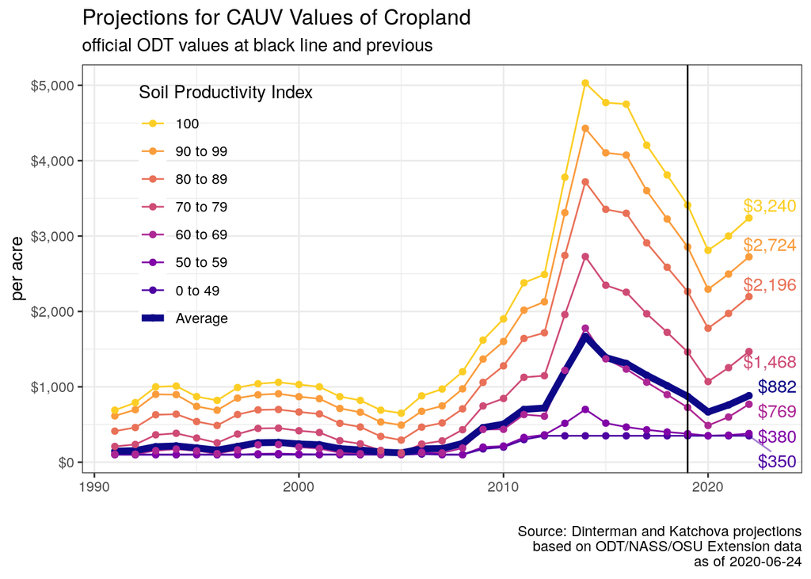

Expected CAUV Projections

| Year | avg_cauv | indx_49 | indx_59 | indx_69 | indx_79 | indx_89 | indx_99 | indx_100 |
| --- | --- | --- | --- | --- | --- | --- | --- | --- |
| 2007 | $181 | $100 | $100 | $123 | $283 | $521 | $747 | $970 |
| 2008 | $249 | $100 | $100 | $188 | $431 | $708 | $973 | $1,200 |
| 2009 | $459 | $176 | $200 | $435 | $746 | $1,059 | $1,368 | $1,620 |
| 2010 | $505 | $200 | $214 | $436 | $845 | $1,278 | $1,601 | $1,900 |
| 2011 | $700 | $300 | $328 | $632 | $1,126 | $1,641 | $2,017 | $2,380 |
| 2012 | $719 | $350 | $363 | $610 | $1,147 | $1,717 | $2,128 | $2,490 |
| 2013 | $1,205 | $350 | $516 | $1,218 | $1,958 | $2,743 | $3,310 | $3,780 |
| 2014 | $1,668 | $350 | $700 | $1,778 | $2,728 | $3,718 | $4,428 | $5,030 |
| 2015 | $1,388 | $350 | $518 | $1,371 | $2,347 | $3,354 | $4,104 | $4,770 |
| 2016 | $1,310 | $350 | $466 | $1,235 | $2,255 | $3,302 | $4,074 | $4,750 |
| 2017 | $1,153 | $350 | $430 | $1,061 | $1,969 | $2,909 | $3,602 | $4,205 |
| 2018 | $1,015 | $350 | $400 | $896 | $1,723 | $2,586 | $3,226 | $3,810 |
| 2019 | $873 | $350 | $378 | $725 | $1,462 | $2,263 | $2,855 | $3,410 |
| 2020 | $666 | $350 | $351 | $487 | $1,069 | $1,777 | $2,294 | $2,810 |
| 2021 | $759 | $350 | $359 | $599 | $1,254 | $1,974 | $2,495 | $3,000 |
| 2022 | $882 | $350 | $380 | $769 | $1,468 | $2,196 | $2,724 | $3,240 |

## High Range

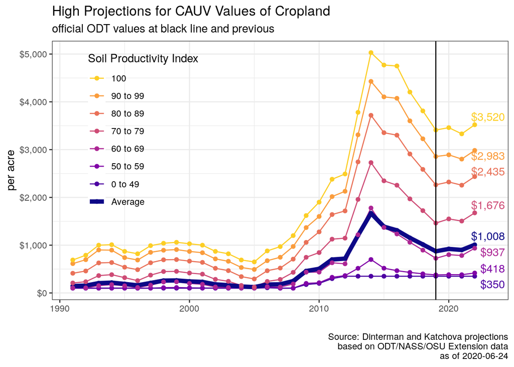

High CAUV Projections

| Year | avg_cauv | indx_49 | indx_59 | indx_69 | indx_79 | indx_89 | indx_99 | indx_100 |
| --- | --- | --- | --- | --- | --- | --- | --- | --- |
| 2007 | $181 | $100 | $100 | $123 | $283 | $521 | $747 | $970 |
| 2008 | $249 | $100 | $100 | $188 | $431 | $708 | $973 | $1,200 |
| 2009 | $459 | $176 | $200 | $435 | $746 | $1,059 | $1,368 | $1,620 |
| 2010 | $505 | $200 | $214 | $436 | $845 | $1,278 | $1,601 | $1,900 |
| 2011 | $700 | $300 | $328 | $632 | $1,126 | $1,641 | $2,017 | $2,380 |
| 2012 | $719 | $350 | $363 | $610 | $1,147 | $1,717 | $2,128 | $2,490 |
| 2013 | $1,205 | $350 | $516 | $1,218 | $1,958 | $2,743 | $3,310 | $3,780 |
| 2014 | $1,668 | $350 | $700 | $1,778 | $2,728 | $3,718 | $4,428 | $5,030 |
| 2015 | $1,388 | $350 | $518 | $1,371 | $2,347 | $3,354 | $4,104 | $4,770 |
| 2016 | $1,310 | $350 | $466 | $1,235 | $2,255 | $3,302 | $4,074 | $4,750 |
| 2017 | $1,153 | $350 | $430 | $1,061 | $1,969 | $2,909 | $3,602 | $4,205 |
| 2018 | $1,015 | $350 | $400 | $896 | $1,723 | $2,586 | $3,226 | $3,810 |
| 2019 | $873 | $350 | $378 | $725 | $1,462 | $2,263 | $2,855 | $3,410 |
| 2020 | $922 | $350 | $383 | $801 | $1,550 | $2,322 | $2,891 | $3,460 |
| 2021 | $900 | $350 | $382 | $784 | $1,505 | $2,255 | $2,802 | $3,330 |
| 2022 | $1,008 | $350 | $418 | $937 | $1,676 | $2,435 | $2,983 | $3,520 |

## Low Range

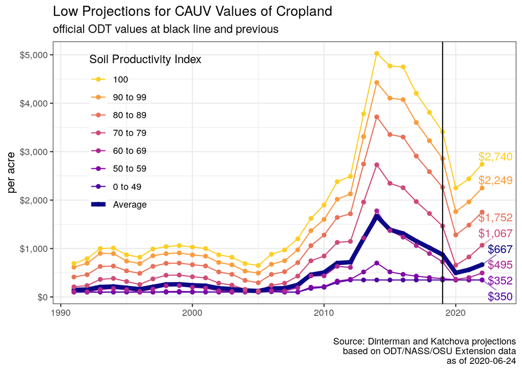

Low CAUV Projections

| Year | avg_cauv | indx_49 | indx_59 | indx_69 | indx_79 | indx_89 | indx_99 | indx_100 |
| --- | --- | --- | --- | --- | --- | --- | --- | --- |
| 2007 | $181 | $100 | $100 | $123 | $283 | $521 | $747 | $970 |
| 2008 | $249 | $100 | $100 | $188 | $431 | $708 | $973 | $1,200 |
| 2009 | $459 | $176 | $200 | $435 | $746 | $1,059 | $1,368 | $1,620 |
| 2010 | $505 | $200 | $214 | $436 | $845 | $1,278 | $1,601 | $1,900 |
| 2011 | $700 | $300 | $328 | $632 | $1,126 | $1,641 | $2,017 | $2,380 |
| 2012 | $719 | $350 | $363 | $610 | $1,147 | $1,717 | $2,128 | $2,490 |
| 2013 | $1,205 | $350 | $516 | $1,218 | $1,958 | $2,743 | $3,310 | $3,780 |
| 2014 | $1,668 | $350 | $700 | $1,778 | $2,728 | $3,718 | $4,428 | $5,030 |
| 2015 | $1,388 | $350 | $518 | $1,371 | $2,347 | $3,354 | $4,104 | $4,770 |
| 2016 | $1,310 | $350 | $466 | $1,235 | $2,255 | $3,302 | $4,074 | $4,750 |
| 2017 | $1,153 | $350 | $430 | $1,061 | $1,969 | $2,909 | $3,602 | $4,205 |
| 2018 | $1,015 | $350 | $400 | $896 | $1,723 | $2,586 | $3,226 | $3,810 |
| 2019 | $873 | $350 | $378 | $725 | $1,462 | $2,263 | $2,855 | $3,410 |
| 2020 | $497 | $350 | $350 | $364 | $656 | $1,281 | $1,761 | $2,250 |
| 2021 | $561 | $350 | $350 | $399 | $825 | $1,483 | $1,964 | $2,440 |
| 2022 | $667 | $350 | $352 | $495 | $1,067 | $1,752 | $2,249 | $2,740 |

# References

- Farm Office annual crop budget reports https://farmoffice.osu.edu/farm-management-tools/farm-budgets
- Ohio Code of Legislation http://codes.ohio.gov/orc/5713.31 and http://codes.ohio.gov/orc/5715.01
- ODT CAUV Information page https://www.tax.ohio.gov/real_property/cauv.aspx
- USDA-NASS price and yield data https://quickstats.nass.usda.gov
- USDA-ERS total rate of return on farm equity data https://www.ers.usda.gov/data-products/farm-income-and-wealth-statistics/data-files-us-and-state-level-farm-income-and-wealth-statistics/
- Projections for 2020 CAUV values are available at https://github.com/rdinter/CAUV/blob/master/3-proj/future/projections_tidy_2020.csv
- Projections for 2021 CAUV values are available at https://github.com/rdinter/CAUV/blob/master/3-proj/future/projections_tidy_2021.csv
- Projections for 2022 CAUV values are available at https://github.com/rdinter/CAUV/blob/master/3-proj/future/projections_tidy_2022.csv